# R Notebook

Run this command when you are working on any lectures or exercises that might depend on the English language (for example, the names for the days of the week).

```r
Sys.setlocale("LC_ALL", "C")
```

```
[1] "C"
```

`r`r seq(0,100,2)

```
 [1]   0   2   4   6   8  10  12  14  16  18  20  22  24  26  28  30  32  34
[19]  36  38  40  42  44  46  48  50  52  54  56  58  60  62  64  66  68  70
[37]  72  74  76  78  80  82  84  86  88  90  92  94  96  98 100
```

rbind() combine dataframes by stacking rows

```r
getwd()
```

```
[1] "C:/Users/WALLI/Desktop/Di/R proj/practice"
```

```r
WHO=read.csv("C:\\Users\\WALLI\\Desktop\\Di\\edx\\Analytic Edge\\WHO.csv")
str(WHO)
```

```
'data.frame':   194 obs. of  13 variables:
 $ Country                      : Factor w/ 194 levels "Afghanistan",..: 1 2 3 4 5 6 7 8 9 10 ...
 $ Region                       : Factor w/ 6 levels "Africa","Americas",..: 3 4 1 4 1 2 2 4 6 4 ...
 $ Population                   : int  29825 3162 38482 78 20821 89 41087 2969 23050 8464 ...
 $ Under15                      : num  47.4 21.3 27.4 15.2 47.6 ...
 $ Over60                       : num  3.82 14.93 7.17 22.86 3.84 ...
 $ FertilityRate                : num  5.4 1.75 2.83 NA 6.1 2.12 2.2 1.74 1.89 1.44 ...
 $ LifeExpectancy               : int  60 74 73 82 51 75 76 71 82 81 ...
 $ ChildMortality               : num  98.5 16.7 20 3.2 163.5 ...
 $ CellularSubscribers          : num  54.3 96.4 99 75.5 48.4 ...
 $ LiteracyRate                 : num  NA NA NA NA 70.1 99 97.8 99.6 NA NA ...
 $ GNI                          : num  1140 8820 8310 NA 5230 ...
 $ PrimarySchoolEnrollmentMale  : num  NA NA 98.2 78.4 93.1 91.1 NA NA 96.9 NA ...
 $ PrimarySchoolEnrollmentFemale: num  NA NA 96.4 79.4 78.2 84.5 NA NA 97.5 NA ...
```

```r
summary(WHO)
```

```
                Country                      Region     Population         Under15
 Afghanistan        :  1   Africa               :46   Min.   :      1   Min.   :13.12
 Albania            :  1   Americas             :35   1st Qu.:   1696   1st Qu.:18.72
 Algeria            :  1   Eastern Mediterranean:22   Median :   7790   Median :28.65
 Andorra            :  1   Europe               :53   Mean   :  36360   Mean   :28.73
 Angola             :  1   South-East Asia      :11   3rd Qu.:  24535   3rd Qu.:37.75
 Antigua and Barbuda:  1   Western Pacific      :27   Max.   :1390000   Max.   :49.99
 (Other)            :188
     Over60      FertilityRate   LifeExpectancy  ChildMortality    CellularSubscribers
 Min.   : 0.81   Min.   :1.260   Min.   :47.00   Min.   :  2.200   Min.   :  2.57
 1st Qu.: 5.20   1st Qu.:1.835   1st Qu.:64.00   1st Qu.:  8.425   1st Qu.: 63.57
 Median : 8.53   Median :2.400   Median :72.50   Median : 18.600   Median : 97.75
 Mean   :11.16   Mean   :2.941   Mean   :70.01   Mean   : 36.149   Mean   : 93.64
 3rd Qu.:16.69   3rd Qu.:3.905   3rd Qu.:76.00   3rd Qu.: 55.975   3rd Qu.:120.81
 Max.   :31.92   Max.   :7.580   Max.   :83.00   Max.   :181.600   Max.   :196.41
                 NA's   :11                                        NA's   :10
  LiteracyRate        GNI        PrimarySchoolEnrollmentMale PrimarySchoolEnrollmentFemale
 Min.   :31.10   Min.   :  340   Min.   : 37.20              Min.   : 32.50
 1st Qu.:71.60   1st Qu.: 2335   1st Qu.: 87.70              1st Qu.: 87.30
 Median :91.80   Median : 7870   Median : 94.70              Median : 95.10
 Mean   :83.71   Mean   :13321   Mean   : 90.85              Mean   : 89.63
 3rd Qu.:97.85   3rd Qu.:17558   3rd Qu.: 98.10              3rd Qu.: 97.90
 Max.   :99.80   Max.   :86440   Max.   :100.00              Max.   :100.00
 NA's   :91      NA's   :32      NA's   :93                  NA's   :93
```

```r
which.min(WHO$Under15)
```

```
[1] 86
```

```r
WHO$Country[86]
```

```
[1] Japan
194 Levels: Afghanistan Albania Algeria Andorra Angola Antigua and Barbuda Argentina ... Zimbabwe
```

```r
WHO$Country[which.min(WHO$Over60)]
```

```
[1] United Arab Emirates
194 Levels: Afghanistan Albania Algeria Andorra Angola Antigua and Barbuda Argentina ... Zimbabwe
```

```r
WHO_Europe = subset(WHO, Region  =="Europe")
str(WHO_Europe)
```

```
'data.frame':   53 obs. of  13 variables:
 $ Country                      : Factor w/ 194 levels "Afghanistan",..: 2 4 8 10 11 16 17 22 26 42 ...
 $ Region                       : Factor w/ 6 levels "Africa","Americas",..: 4 4 4 4 4 4 4 4 4 4 ...
 $ Population                   : int  3162 78 2969 8464 9309 9405 11060 3834 7278 4307 ...
 $ Under15                      : num  21.3 15.2 20.3 14.5 22.2 ...
 $ Over60                       : num  14.93 22.86 14.06 23.52 8.24 ...
 $ FertilityRate                : num  1.75 NA 1.74 1.44 1.96 1.47 1.85 1.26 1.51 1.48 ...
 $ LifeExpectancy               : int  74 82 71 81 71 71 80 76 74 77 ...
 $ ChildMortality               : num  16.7 3.2 16.4 4 35.2 5.2 4.2 6.7 12.1 4.7 ...
 $ CellularSubscribers          : num  96.4 75.5 103.6 154.8 108.8 ...
 $ LiteracyRate                 : num  NA NA 99.6 NA NA NA NA 97.9 NA 98.8 ...
 $ GNI                          : num  8820 NA 6100 42050 8960 ...
 $ PrimarySchoolEnrollmentMale  : num  NA 78.4 NA NA 85.3 NA 98.9 86.5 99.3 94.8 ...
 $ PrimarySchoolEnrollmentFemale: num  NA 79.4 NA NA 84.1 NA 99.2 88.4 99.7 97 ...
```

`r`r hist(WHO$CellularSubscribers)

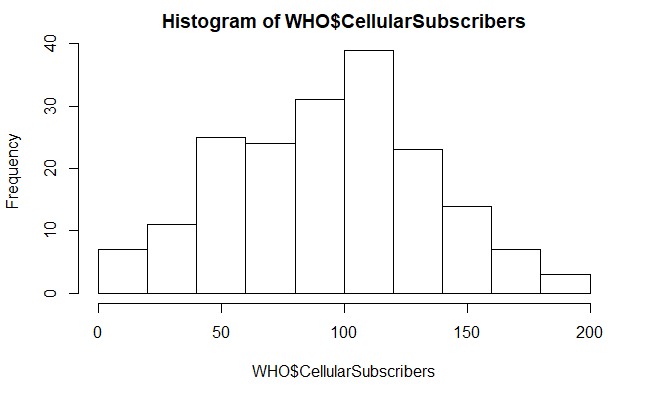

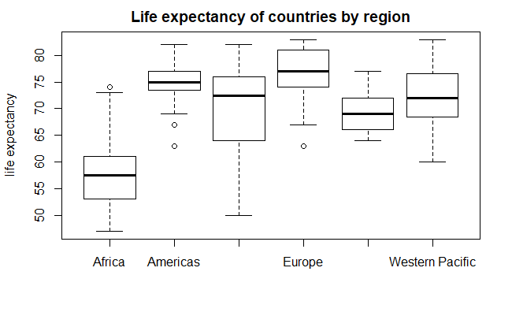

Outliers computed as any points greater than the third quartile plus 1.5*IQR, or less than the first quartile minus 1.5*IQR.

`r`r table(WHO$Region)

```
               Africa              Americas
                   46                    35
Eastern Mediterranean                Europe
                   22                    53
      South-East Asia       Western Pacific
                   11                    27
```

`r`r tapply(WHO$Over60, WHO$Region, mean)

```
               Africa              Americas
             5.220652             10.943714
Eastern Mediterranean                Europe
             5.620000             19.774906
      South-East Asia       Western Pacific
             8.769091             10.162963
```

`r`r tapply(WHO$LiteracyRate, WHO$Region, min, na.rm = TRUE)

```
               Africa              Americas Eastern Mediterranean                Europe
                 31.1                  75.2                  63.9                  95.2
      South-East Asia       Western Pacific
                 56.8                  60.6
```

```r
USDA=read.csv("C:\\Users\\WALLI\\Desktop\\Di\\edx\\Analytic Edge\\USDA.csv")
```

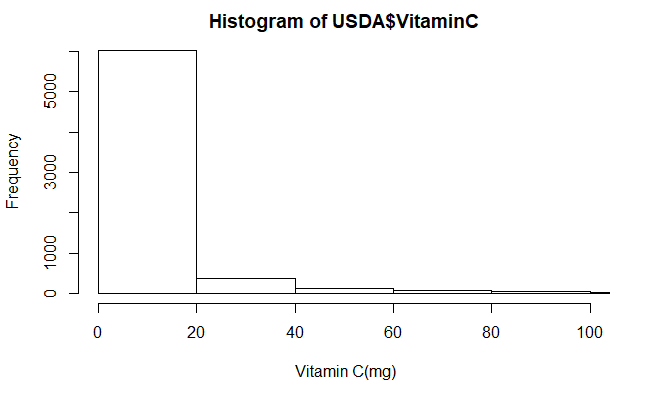

Adding new variable

```r
HighSodium = as.numeric(USDA$Sodium > mean(USDA$Sodium, na.rm= TRUE))
str(HighSodium)
```

```
 num [1:7058] 1 1 0 1 1 1 1 1 1 1 ...
```

```r
USDA$HighSodium = HighSodium
```

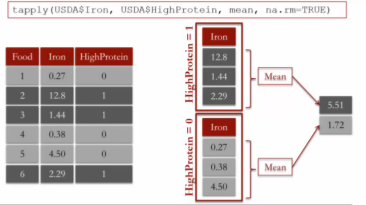

Using tapply()

```r
USDA$HighFat = as.numeric(USDA$TotalFat > mean(USDA$TotalFat, na.rm= TRUE))
table(USDA$HighSodium, USDA$HighFat)
```

```
       0    1
  0 3529 1355
  1 1378  712
```

```r
tapply(USDA$VitaminC,USDA$HighSodium, summary, na.rm = TRUE)
```

```
$`0`
   Min. 1st Qu.  Median    Mean 3rd Qu.    Max.    NA's
   0.00    0.00    0.00   10.72    4.00 2400.00     154

$`1`
   Min. 1st Qu.  Median    Mean 3rd Qu.    Max.    NA's
  0.000   0.000   0.000   6.202   1.500 560.000     116
```

Date conversion

```r
mvt=read.csv("C:/Users/WALLI/Desktop/Di/edx/Analytic Edge/mvtWeek1.csv")
DateConvert = as.Date(strptime(mvt$Date, "%m/%d/%y %H:%M"))
summary(DateConvert)
```

```
        Min.      1st Qu.       Median         Mean      3rd Qu.         Max.
"2001-01-01" "2003-07-10" "2006-05-21" "2006-08-23" "2009-10-24" "2012-12-31"
```

```r
mvt$Month = months(DateConvert)
mvt$Weekday = weekdays(DateConvert)
mvt$Date = DateConvert
```

```r
sort(table(mvt$LocationDescription))
```

```
    AIRPORT BUILDING NON-TERMINAL - SECURE AREA                  AIRPORT EXTERIOR - SECURE AREA
                                              1                                               1
                                ANIMAL HOSPITAL                                 APPLIANCE STORE
                                              1                                               1
                                      CTA TRAIN                         JAIL / LOCK-UP FACILITY
                                              1                                               1
                                      NEWSSTAND                                          BRIDGE
                                              1                                               2
              COLLEGE/UNIVERSITY RESIDENCE HALL                               CURRENCY EXCHANGE
                                              2                                               2
                                  BOWLING ALLEY                                  CLEANING STORE
                                              3                                               3
                          MEDICAL/DENTAL OFFICE                              ABANDONED BUILDING
                                              3                                               4
AIRPORT BUILDING NON-TERMINAL - NON-SECURE AREA                                      BARBERSHOP
                                              4                                               4
                 LAKEFRONT/WATERFRONT/RIVERBANK                                         LIBRARY
                                              4                                               4
                               SAVINGS AND LOAN  AIRPORT TERMINAL UPPER LEVEL - NON-SECURE AREA
                                              4                                               5
                                  CHA APARTMENT                                 DAY CARE CENTER
                                              5                                               5
                                   FIRE STATION                                 FOREST PRESERVE
                                              5                                               6
                                           BANK                               CONVENIENCE STORE
                                              7                                               7
                                     DRUG STORE                 OTHER COMMERCIAL TRANSPORTATION
                                              8                                               8
                                  ATHLETIC CLUB                   AIRPORT VENDING ESTABLISHMENT
                                              9                                              10
                            AIRPORT PARKING LOT                       SCHOOL, PRIVATE, BUILDING
                                             11                                              14
                            TAVERN/LIQUOR STORE                  FACTORY/MANUFACTURING BUILDING
                                             14                                              16
                                  BAR OR TAVERN                                       WAREHOUSE
                                             17                                              17
                            MOVIE HOUSE/THEATER                         RESIDENCE PORCH/HALLWAY
                                             18                                              18
                   NURSING HOME/RETIREMENT HOME                                         TAXICAB
                                             21                                              21
```

[output cut: 23 more lines]

```
                                            255                                             266
                               AIRPORT/AIRCRAFT                         CHA PARKING LOT/GROUNDS
                                            363                                             405
                                       SIDEWALK                          VEHICLE NON-COMMERCIAL
                                            462                                             817
                                VACANT LOT/LAND                                RESIDENCE-GARAGE
                                            985                                            1176
                                      RESIDENCE                   RESIDENTIAL YARD (FRONT/BACK)
                                           1302                                            1536
                         DRIVEWAY - RESIDENTIAL                                     GAS STATION
                                           1675                                            2111
                                          ALLEY                                           OTHER
                                           2308                                            4573
                 PARKING LOT/GARAGE(NON.RESID.)                                          STREET
                                          14852                                          156564
```

```r
Top5=subset(mvt, mvt$LocationDescription %in% c("STREET", "PARKING LOT/GARAGE(NON.RESID.)", "ALLEY", "GAS STATION", "DRIVEWAY - RESIDENTIAL" ))
Top5$LocationDescription = factor(Top5$LocationDescription)
```

```r
plot(CocaCola$Date, CocaCola$StockPrice, type = "l", col = "red")
```

[output not shown]

```r
tapply(IBM$StockPrice, months(IBM$Date), summary)
```

Analysing NA values

```r
CPS=read.csv("C:/Users/WALLI/Desktop/Di/edx/Analytic Edge/CPSData.csv")
table(CPS$Sex, is.na(CPS$Married))
```

```
         FALSE  TRUE
  Female 55264 12217
  Male   50700 13121
```

Computing proportions

```r
tapply(is.na(CPS$MetroAreaCode), CPS$State, mean)
```

```
             Alabama               Alaska              Arizona             Arkansas
          0.25872093           1.00000000           0.13154450           0.49049965
          California             Colorado          Connecticut             Delaware
          0.02048401           0.12991453           0.08568406           0.23396567
District of Columbia              Florida              Georgia               Hawaii
          0.00000000           0.03923092           0.19843249           0.24916627
               Idaho             Illinois              Indiana                 Iowa
          0.49868248           0.11221881           0.29141717           0.48694620
              Kansas             Kentucky            Louisiana                Maine
          0.36227390           0.50678979           0.16137931           0.59832081
            Maryland        Massachusetts             Michigan            Minnesota
          0.06937500           0.06492199           0.17825661           0.31506849
         Mississippi             Missouri              Montana             Nebraska
          0.69430894           0.32867133           0.83607908           0.58132376
              Nevada        New Hampshire           New Jersey           New Mexico
          0.13308190           0.56874530           0.00000000           0.24500907
            New York       North Carolina         North Dakota                 Ohio
          0.08060769           0.37304315           0.73738602           0.25122349
            Oklahoma               Oregon         Pennsylvania         Rhode Island
          0.32764281           0.21821925           0.17430025           0.00000000
      South Carolina         South Dakota            Tennessee                Texas
          0.31302774           0.70250000           0.35594170           0.14370496
                Utah              Vermont             Virginia           Washington
          0.21009772           0.65238095           0.19844226           0.18131868
       West Virginia            Wisconsin              Wyoming
          0.75585522           0.29932986           1.00000000
```

```r
sort(tapply(CPS$Race == "Asian" ,CPS$MetroArea,  mean))
```

```
      10500       11020       11100       11300       11540       11700       13140       13740
0.000000000 0.000000000 0.000000000 0.000000000 0.000000000 0.000000000 0.000000000 0.000000000
      13780       14020       14540       15940       16620       17020       17980       19500
0.000000000 0.000000000 0.000000000 0.000000000 0.000000000 0.000000000 0.000000000 0.000000000
      20500       20740       21340       21500       22140       22460       25180       26620
0.000000000 0.000000000 0.000000000 0.000000000 0.000000000 0.000000000 0.000000000 0.000000000
      27100       27140       27500       27740       27900       28100       28660       28700
0.000000000 0.000000000 0.000000000 0.000000000 0.000000000 0.000000000 0.000000000 0.000000000
      28940       29180       29620       29700       30980       31180       31340       31420
0.000000000 0.000000000 0.000000000 0.000000000 0.000000000 0.000000000 0.000000000 0.000000000
      31460       32580       33140       33260       33780       34740       34820       35660
0.000000000 0.000000000 0.000000000 0.000000000 0.000000000 0.000000000 0.000000000 0.000000000
      36140       36780       38940       39100       39380       39460       39540       39740
0.000000000 0.000000000 0.000000000 0.000000000 0.000000000 0.000000000 0.000000000 0.000000000
      40220       40420       40980       41060       41420       41540       42100       42140
0.000000000 0.000000000 0.000000000 0.000000000 0.000000000 0.000000000 0.000000000 0.000000000
      42540       43340       43780       43900       44220       45220       46220       46540
0.000000000 0.000000000 0.000000000 0.000000000 0.000000000 0.000000000 0.000000000 0.000000000
      46660       46940       47020       47220       47380       48140       70900       74500
0.000000000 0.000000000 0.000000000 0.000000000 0.000000000 0.000000000 0.000000000 0.000000000
      78100       78700       41180       35380       41700       16700       33740       16860
0.000000000 0.000000000 0.002092050 0.002724796 0.003294893 0.004310345 0.005586592 0.005988024
      33700       13460       19380       42060       42220       45780       17660       49620
0.006329114 0.007142857 0.007462687 0.007575758 0.007751938 0.008510638 0.008547009 0.008547009
      49420       24340       43620       21780       29940       17460       30020       14260
0.008928571 0.009868421 0.010084034 0.010101010 0.010204082 0.010279001 0.010309278 0.010869565
      25420       28740       31140       32780       24540       44180       13820       47940
0.011494253 0.011494253 0.011560694 0.012195122 0.012345679 0.012422360 0.012755102 0.012820513
      39340       49660       36100       10900       18580       20100       16740       42260
0.012944984 0.013071895 0.013157895 0.014970060 0.015151515 0.015350877 0.015473888 0.015625000
      28020       49180       27780       17820       16580       34900       37460       32820
0.015748031 0.015748031 0.015873016 0.016129032 0.016393443 0.016393443 0.016949153 0.017241379
      18140       39140       29740       37860       44060       22660       22420       42340
0.018148820 0.018518519 0.018691589 0.018691589 0.019230769 0.019417476 0.019607843 0.019801980
      46060       20940       21660       19340       19660       45820       17140       30780
0.019867550 0.020202020 0.020408163 0.020833333 0.021428571 0.021978022 0.022253129 0.022277228
      10580       12940       14740       70750       34940       26900       12260       26100
0.022388060 0.022900763 0.022988506 0.024038462 0.024390244 0.024561404 0.024844720 0.025641026
      22180       36260       77350       47260       29460       17900       22020       13380
0.025974026 0.026004728 0.026717557 0.026800670 0.026845638 0.027491409 0.027777778 0.028571429
```

[output cut: 11 more lines]

```
0.047619048 0.047619048 0.048346056 0.048706240 0.049180328 0.049535604 0.050595238 0.050819672
      22220       42020       71650       12420       15380       44100       26980       37900
0.051162791 0.051948052 0.052041274 0.052325581 0.052325581 0.052631579 0.053435115 0.053571429
      31540       32900       22900       34980       29540       12580       39900       16980
0.056338028 0.056603774 0.057142857 0.057425743 0.057692308 0.057990560 0.058064516 0.058441558
      14500       26420       40140       72850       19100       17860       40380       16300
0.058479532 0.061249242 0.062015504 0.062500000 0.062801932 0.063829787 0.065146580 0.066326531
      73450       38900       47900       12060       76450       29340       37100       14060
0.066666667 0.069788797 0.070624850 0.072809278 0.073891626 0.074074074 0.074906367 0.075000000
      15180       33460       29820       24660       12540       11460       29100       24580
0.075949367 0.076725026 0.078521940 0.079681275 0.081632653 0.082352941 0.087719298 0.088235294
      47300       42660       35620       41500       36500       31100       41740       40900
0.090909091 0.099601594 0.104270660 0.125000000 0.131313131 0.135056070 0.142227122 0.142428786
      12100       44700       47580       23420       46700       41940       41860       26180
0.144144144 0.155440415 0.166666667 0.184818482 0.203007519 0.241791045 0.246753247 0.501903553
```

Merging

```r
MetroAreaMap=read.csv("C:/Users/WALLI/Desktop/Di/edx/Analytic Edge/MetroAreaCodes.csv")
CPS = merge(CPS, MetroAreaMap, by.x="MetroAreaCode", by.y="Code", all.x=TRUE)
```

The first two arguments determine the data frames to be merged (they are called “x” and “y”, respectively, in the subsequent parameters to the merge function). by.x=“MetroAreaCode” means we’re matching on the MetroAreaCode variable from the “x” data frame (CPS), while by.y=“Code” means we’re matching on the Code variable from the “y” data frame (MetroAreaMap). Finally, all.x=TRUE means we want to keep all rows from the “x” data frame (CPS), even if some of the rows’ MetroAreaCode doesn’t match any codes in MetroAreaMap (for those familiar with database terminology, this parameter makes the operation a left outer join instead of an inner join).

To obtain the number of TRUE values in a vector of TRUE/FALSE values, you can use the sum() function. For instance, sum(c(TRUE, FALSE, TRUE, TRUE)) is 3. Therefore, we can obtain counts of people born in a particular country living in a particular metropolitan area with:

```r
sort(tapply(CPS$Country == "India", CPS$MetroArea, sum, na.rm=TRUE))
```

```
                                         Akron, OH
                                                 0
                       Albany-Schenectady-Troy, NY
                                                 0
                                        Albany, GA
                                                 0
                                   Albuquerque, NM
                                                 0
                 Allentown-Bethlehem-Easton, PA-NJ
                                                 0
                                       Altoona, PA
                                                 0
                                      Amarillo, TX
                                                 0
                                      Anderson, IN
                                                 0
                                      Anderson, SC
                                                 0
                                     Ann Arbor, MI
                                                 0
                               Anniston-Oxford, AL
                                                 0
                                       Appleton,WI
                                                 0
                                     Asheville, NC
                                                 0
                           Athens-Clark County, GA
                                                 0
                Atlanta-Sandy Springs-Marietta, GA
                                                 0
                                 Atlantic City, NJ
                                                 0
                    Augusta-Richmond County, GA-SC
                                                 0
                             Austin-Round Rock, TX
                                                 0
                                   Bakersfield, CA
                                                 0
                              Baltimore-Towson, MD
                                                 0
```

[output cut: 473 more lines]

```
                                                 0
                                        Wausau, WI
                                                 0
                                       Wichita, KS
                                                 0
                                 Winston-Salem, NC
                                                 0
                                  Worcester, MA-CT
                                                 0
                                        Yakima, WA
                                                 0
                                  York-Hanover, PA
                                                 0
                    Youngstown-Warren-Boardman, OH
                                                 0
```

Linera regression

```r
wine= read.csv("C:/Users/WALLI/Desktop/Di/edx/Analytic Edge/wine.csv")
model = lm(Price ~ AGST, data = wine )
summary(model)
```

```
Call:
lm(formula = Price ~ AGST, data = wine)

Residuals:
     Min       1Q   Median       3Q      Max
-0.78450 -0.23882 -0.03727  0.38992  0.90318

Coefficients:
            Estimate Std. Error t value Pr(>|t|)
(Intercept)  -3.4178     2.4935  -1.371 0.183710
AGST          0.6351     0.1509   4.208 0.000335 ***
---
Signif. codes:  0 ‘***’ 0.001 ‘**’ 0.01 ‘*’ 0.05 ‘.’ 0.1 ‘ ’ 1

Residual standard error: 0.4993 on 23 degrees of freedom
Multiple R-squared:  0.435, Adjusted R-squared:  0.4105
F-statistic: 17.71 on 1 and 23 DF,  p-value: 0.000335
```

SSE

```r
SSE=sum(model$residuals^2)
SSE
```

```
[1] 5.734875
```

Correlation

```r
cor(wine$WinterRain, wine$Price)
```

```
[1] 0.1366505
```

```r
cor(wine)
```

```
                   Year      Price   WinterRain        AGST HarvestRain         Age
Year         1.00000000 -0.4477679  0.016970024 -0.24691585  0.02800907 -1.00000000
Price       -0.44776786  1.0000000  0.136650547  0.65956286 -0.56332190  0.44776786
WinterRain   0.01697002  0.1366505  1.000000000 -0.32109061 -0.27544085 -0.01697002
AGST        -0.24691585  0.6595629 -0.321090611  1.00000000 -0.06449593  0.24691585
HarvestRain  0.02800907 -0.5633219 -0.275440854 -0.06449593  1.00000000 -0.02800907
Age         -1.00000000  0.4477679 -0.016970024  0.24691585 -0.02800907  1.00000000
FrancePop    0.99448510 -0.4668616 -0.001621627 -0.25916227  0.04126439 -0.99448510
               FrancePop
Year         0.994485097
Price       -0.466861641
WinterRain  -0.001621627
AGST        -0.259162274
HarvestRain  0.041264394
Age         -0.994485097
FrancePop    1.000000000
```

Prediction

```r
wineTest=read.csv("C:/Users/WALLI/Desktop/Di/edx/Analytic Edge//wine_test.csv")
predictTest=predict(model, newdata = wineTest)
predictTest
```

```
       1        2
6.849618 6.743748
```

```r
SSE=sum((wineTest$Price - predictTest)^2)
SST=sum((wineTest$Price - mean(wine$Price))^2)
1-SSE/SST
```

```
[1] 0.7882105
```

Change reference level for factor variable

```r
pisa_train = read.csv("C:/Users/WALLI/Desktop/Di/edx/Analytic Edge/pisa2009train.csv")
pisa_test= read.csv("C:/Users/WALLI/Desktop/Di/edx/Analytic Edge/pisa2009test.csv")
pisa_train$raceeth = relevel(pisa_train$raceeth, "White")
pisa_test$raceeth = relevel(pisa_test$raceeth, "White")
```

```r
pisa_test_pr=predict(lm_pisa, newdata = pisa_test)
```

[output not shown]

Library for spliting data into data and test

```r
library(caTools)
quality = read.csv("C:/Users/WALLI/Desktop/Di/edx/Analytic Edge/quality.csv")
# Randomly split data
set.seed(88)
split = sample.split(quality$PoorCare, SplitRatio = 0.75)
split
```

```
  [1]  TRUE  TRUE  TRUE  TRUE FALSE  TRUE FALSE  TRUE FALSE FALSE  TRUE FALSE  TRUE  TRUE  TRUE
 [16]  TRUE  TRUE  TRUE  TRUE  TRUE  TRUE  TRUE  TRUE  TRUE FALSE  TRUE  TRUE  TRUE  TRUE FALSE
 [31] FALSE FALSE FALSE  TRUE  TRUE  TRUE FALSE  TRUE  TRUE  TRUE FALSE FALSE  TRUE  TRUE FALSE
 [46]  TRUE FALSE  TRUE FALSE  TRUE  TRUE FALSE FALSE  TRUE  TRUE  TRUE  TRUE  TRUE  TRUE  TRUE
 [61]  TRUE  TRUE  TRUE  TRUE  TRUE FALSE  TRUE  TRUE  TRUE  TRUE FALSE  TRUE  TRUE  TRUE  TRUE
 [76]  TRUE  TRUE  TRUE  TRUE  TRUE  TRUE  TRUE  TRUE FALSE  TRUE  TRUE  TRUE  TRUE  TRUE  TRUE
 [91]  TRUE  TRUE  TRUE FALSE  TRUE  TRUE  TRUE  TRUE  TRUE  TRUE  TRUE  TRUE  TRUE FALSE  TRUE
[106]  TRUE  TRUE FALSE  TRUE FALSE FALSE  TRUE  TRUE FALSE  TRUE  TRUE  TRUE FALSE  TRUE  TRUE
[121] FALSE  TRUE  TRUE FALSE  TRUE  TRUE FALSE  TRUE  TRUE  TRUE FALSE
```

```r
# Create training and testing sets
qualityTrain = subset(quality, split == TRUE)
qualityTest = subset(quality, split == FALSE)
```

Logistic Regression Model

```r
QualityLog = glm(PoorCare ~ OfficeVisits + Narcotics, data=qualityTrain, family=binomial)
summary(QualityLog)
```

```
Call:
glm(formula = PoorCare ~ OfficeVisits + Narcotics, family = binomial,
    data = qualityTrain)

Deviance Residuals:
     Min        1Q    Median        3Q       Max
-2.06303  -0.63155  -0.50503  -0.09689   2.16686

Coefficients:
             Estimate Std. Error z value Pr(>|z|)
(Intercept)  -2.64613    0.52357  -5.054 4.33e-07 ***
OfficeVisits  0.08212    0.03055   2.688  0.00718 **
Narcotics     0.07630    0.03205   2.381  0.01728 *
---
Signif. codes:  0 ‘***’ 0.001 ‘**’ 0.01 ‘*’ 0.05 ‘.’ 0.1 ‘ ’ 1

(Dispersion parameter for binomial family taken to be 1)

    Null deviance: 111.888  on 98  degrees of freedom
Residual deviance:  89.127  on 96  degrees of freedom
AIC: 95.127

Number of Fisher Scoring iterations: 4
```

```r
predictTrain = predict(QualityLog, type="response")
```

Analyze predictions

```r
summary(predictTrain)
```

```
   Min. 1st Qu.  Median    Mean 3rd Qu.    Max.
0.06623 0.11910 0.15970 0.25250 0.26760 0.98460
```

```r
tapply(predictTrain, qualityTrain$PoorCare, mean)
```

```
        0         1
0.1894512 0.4392246
```

# Confusion matrix for threshold of 0.5

```r
table(qualityTrain$PoorCare, predictTrain > 0.5)
```

```
    FALSE TRUE
  0    70    4
  1    15   10
```

Generate ROC curve

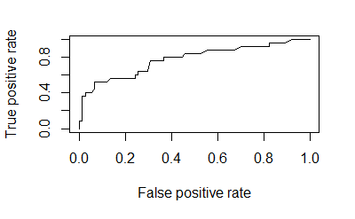

```r
library(ROCR)
ROCRpred = prediction(predictTrain, qualityTrain$PoorCare)
# Performance function
ROCRperf = performance(ROCRpred, "tpr", "fpr")
# Plot ROC curve
plot(ROCRperf)
```

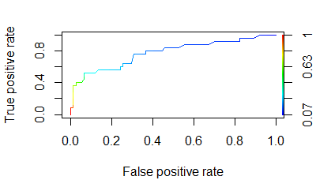

```r
# Add colors
plot(ROCRperf, colorize=TRUE)
```

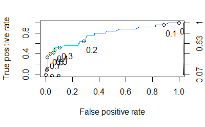

```r
# Add threshold labels
plot(ROCRperf, colorize=TRUE, print.cutoffs.at=seq(0,1,by=0.1), text.adj=c(-0.2,1.7))
```

Computing AUC The AUC of a model has the following nice interpretation: given a random patient from the dataset who actually received poor care, and a random patient from the dataset who actually received good care, the AUC is the perecentage of time that our model will classify which is which correctly.

```r
predictTest = predict(QualityLog, type="response", newdata=qualityTest)
ROCRpredTest = prediction(predictTest, qualityTest$PoorCare)
auc = as.numeric(performance(ROCRpredTest, "auc")@y.values)
```

```r
# Multiple imputation
polling = read.csv("C:/Users/WALLI/Desktop/Di/edx/Analytic Edge/PollingData.csv")
simple = polling[c("Rasmussen", "SurveyUSA", "PropR", "DiffCount")]
summary(simple)
```

```
   Rasmussen          SurveyUSA            PropR          DiffCount
 Min.   :-41.0000   Min.   :-33.0000   Min.   :0.0000   Min.   :-19.000
 1st Qu.: -8.0000   1st Qu.:-11.7500   1st Qu.:0.0000   1st Qu.: -6.000
 Median :  1.0000   Median : -2.0000   Median :0.6250   Median :  1.000
 Mean   :  0.0404   Mean   : -0.8243   Mean   :0.5259   Mean   : -1.269
 3rd Qu.:  8.5000   3rd Qu.:  8.0000   3rd Qu.:1.0000   3rd Qu.:  4.000
 Max.   : 39.0000   Max.   : 30.0000   Max.   :1.0000   Max.   : 11.000
 NA's   :46         NA's   :71
```

```r
set.seed(144)
library("mice")
imputed = complete(mice(simple))
summary(imputed)
```

```
   Rasmussen         SurveyUSA           PropR          DiffCount
 Min.   :-41.000   Min.   :-33.000   Min.   :0.0000   Min.   :-19.000
 1st Qu.: -8.000   1st Qu.:-11.000   1st Qu.:0.0000   1st Qu.: -6.000
 Median :  3.000   Median :  1.000   Median :0.6250   Median :  1.000
 Mean   :  1.731   Mean   :  1.517   Mean   :0.5259   Mean   : -1.269
 3rd Qu.: 11.000   3rd Qu.: 18.000   3rd Qu.:1.0000   3rd Qu.:  4.000
 Max.   : 39.000   Max.   : 30.000   Max.   :1.0000   Max.   : 11.000
```

```r
polling$Rasmussen = imputed$Rasmussen
polling$SurveyUSA = imputed$SurveyUSA
summary(polling)
```

```
         State          Year        Rasmussen         SurveyUSA         DiffCount
 Arizona    :  3   Min.   :2004   Min.   :-41.000   Min.   :-33.000   Min.   :-19.000
 Arkansas   :  3   1st Qu.:2004   1st Qu.: -8.000   1st Qu.:-11.000   1st Qu.: -6.000
 California :  3   Median :2008   Median :  3.000   Median :  1.000   Median :  1.000
 Colorado   :  3   Mean   :2008   Mean   :  1.731   Mean   :  1.517   Mean   : -1.269
 Connecticut:  3   3rd Qu.:2012   3rd Qu.: 11.000   3rd Qu.: 18.000   3rd Qu.:  4.000
 Florida    :  3   Max.   :2012   Max.   : 39.000   Max.   : 30.000   Max.   : 11.000
 (Other)    :127
     PropR          Republican
 Min.   :0.0000   Min.   :0.0000
 1st Qu.:0.0000   1st Qu.:0.0000
 Median :0.6250   Median :1.0000
 Mean   :0.5259   Mean   :0.5103
 3rd Qu.:1.0000   3rd Qu.:1.0000
 Max.   :1.0000   Max.   :1.0000
```

Remove variables from datasets

```r
# To do this, we can use the following trick. First define a vector of variable names called nonvars #- these are the variables that we won't use in our model.
songs=read.csv("C:/Users/WALLI/Desktop/Di/edx/Analytic Edge/songs.csv")
songtrain=subset(songs, songs$year <= 2009)
songtest=subset(songs, songs$year > 2009)
nonvars = c("year", "songtitle", "artistname", "songID", "artistID")
#To remove these variables from your training and testing sets, type the following commands in your R #console:
songtrain = songtrain[ , !(names(songtrain) %in% nonvars) ]
songtest = songtest[ , !(names(songtest) %in% nonvars) ]
```

Substract variable from model

```r
SongsLog2 = glm(Top10 ~ . - loudness, data=songtrain, family=binomial)
```

But this approach (subtracting the variable from the model formula) will always work when you want to remove *numeric variables*.

Trees

```r
stevens = read.csv("C:\\Users\\WALLI\\Desktop\\Di\\edx\\Analytic Edge\\stevens.csv")
```